## Homework 2

*Akshay Kumar Varanasi (av32826)*

**This homework is due on Feb. 5, 2019 at 4:00pm. Please submit as a PDF file on Canvas.**

This homework uses the `Cars93` data set. Each observation in the data frame contains information on passenger cars from 1993. This is a big data frame with 27 columns. We are interested in the information on manufacturer (`Manufacturer`), car model (`Model`), type of car (`Type`), car company origin (`Origin`), midrange price in $1000 (`Price`), city MPG (miles per US gallon, `MPG.city`), and fuel tank capacity in gallons (`Fuel.tank.capacity`).

```r
Cars93 <- read.csv("http://wilkelab.org/classes/SDS348/data_sets/Cars93.csv")
head(Cars93)
```

```
##   Manufacturer   Model    Type Min.Price Price Max.Price MPG.city
## 1        Acura Integra   Small      12.9  15.9      18.8       25
## 2        Acura  Legend Midsize      29.2  33.9      38.7       18
## 3         Audi      90 Compact      25.9  29.1      32.3       20
## 4         Audi     100 Midsize      30.8  37.7      44.6       19
## 5          BMW    535i Midsize      23.7  30.0      36.2       22
## 6        Buick Century Midsize      14.2  15.7      17.3       22
##   MPG.highway            AirBags DriveTrain Cylinders EngineSize
## 1          31               None      Front         4        1.8
## 2          25 Driver & Passenger      Front         6        3.2
## 3          26        Driver only      Front         6        2.8
## 4          26 Driver & Passenger      Front         6        2.8
## 5          30        Driver only       Rear         4        3.5
## 6          31        Driver only      Front         4        2.2
##   Horsepower  RPM Rev.per.mile Man.trans.avail Fuel.tank.capacity
```

[output cut: 20 more lines]

**Problem 1: (2 pts)** Use ggplot2 to create a scatter plot of the city MPG versus the car prices. In the same plot, fit a curve to these data using `geom_smooth()`. In one sentence, what broad trend do you observe in city MPG for different car prices? **HINT**: Plot city MPG on the y-axis and price on the x-axis.

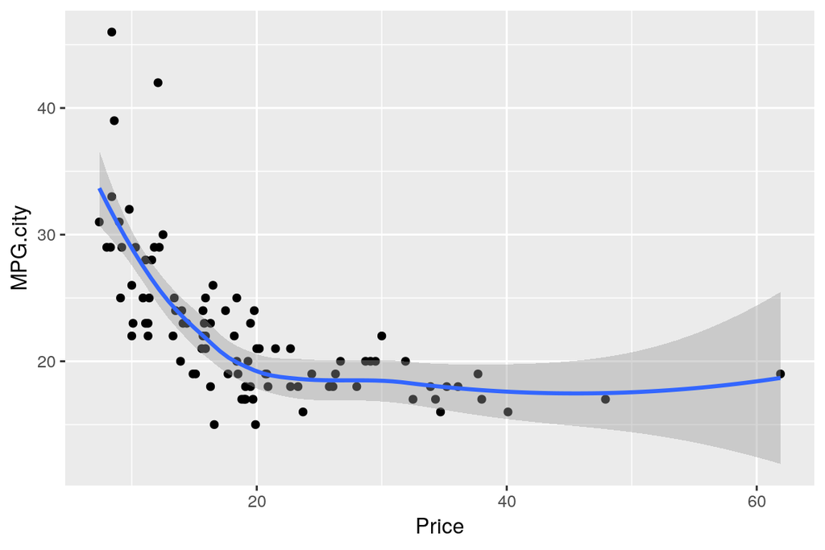

```r
ggplot(Cars93,aes(x=Price,y=MPG.city))+geom_point()+geom_smooth()
```

City MPG decreases initially and attains a constant value as the prices of consumer cars increase.

**Problem 2: (4 pts)** Next, create a bar plot that shows the origin of cars, stacked on top of each other, for each car type. Make two observations about the data from this plot. State each in 1 sentence.

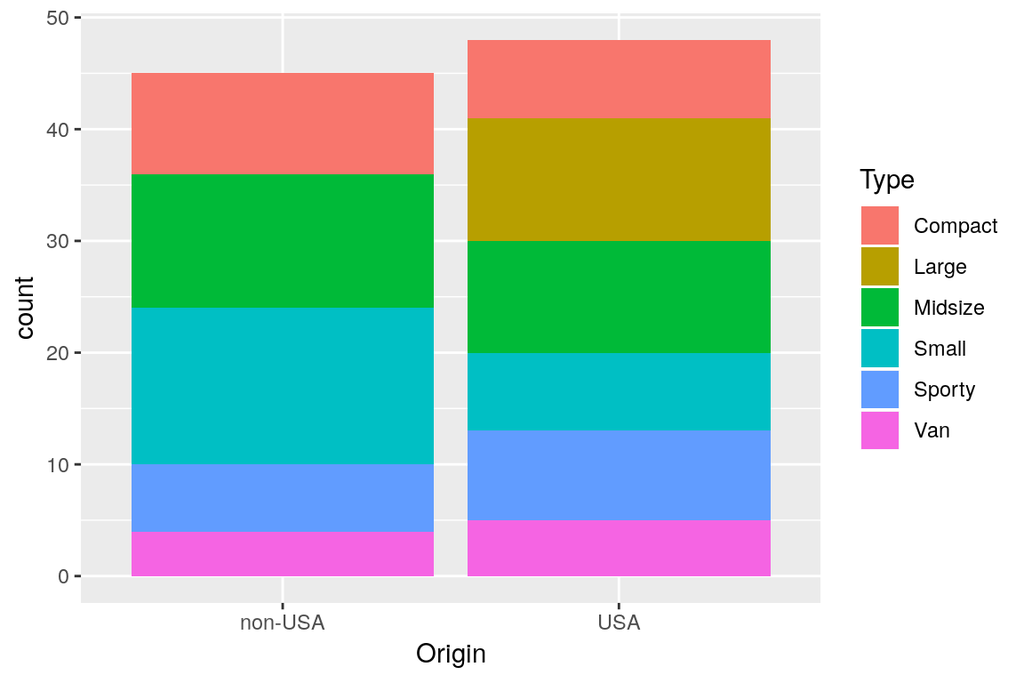

```r
ggplot(Cars93,aes(x=Origin,fill=Type))+geom_bar()
```

Car Manufacturers of US origin produce mostly bigger cars whereas those from other countries prefer to produce small cars. And number of cars produced by US manufacturers is more than the foreign manufacturers.

**Problem 3: (2 pts)** Plot the distribution of fuel tank capacity, once using `geom_histogram()` and once using `geom_density()`.

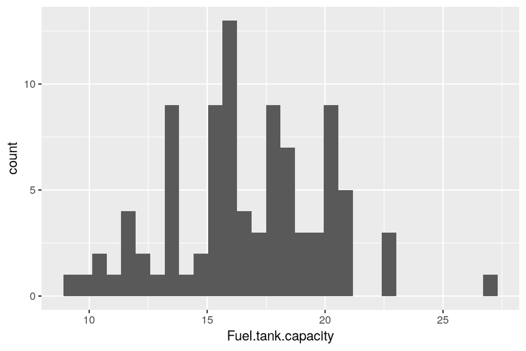

```r
# Histogram
ggplot(Cars93,aes(x=Fuel.tank.capacity))+geom_histogram()
```

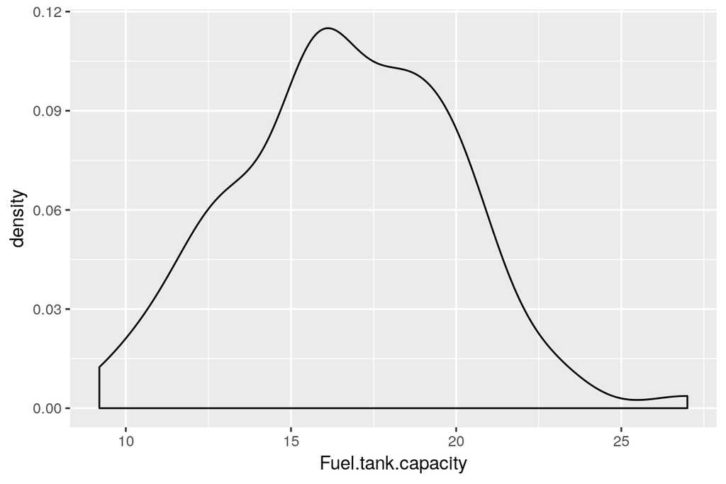

```r
# Density
ggplot(Cars93,aes(x=Fuel.tank.capacity))+geom_density()#+geom_vline(aes(xintercept=mean(Fuel.tank.capacity)), color="blue", linetype="dashed", size=1) #for
```

**Problem 4: (2 pts)** What does the y-axis in your histogram represent? In your density plot, what is the *total* area under the curve? For the total area, please give a single number as your answer. **HINT**: You do not need to do any additional calculations to determine the area under the curve. Use Google to find the answer.

The y-axis in histogram represents how many cars are there within that range(bin) of Fuel tank capacity values. And since the density plot is probability density function, area should be 1.